# Chicago Bulls 2019-20 Roster Targets

Andrew Mellor

2020-05-24

[figure not shown]

# Scenario and Aim of this Data Analysis

In the most recent NBA season (2018-19), the Chicago Bulls placed 27th out of 30 (a 22-60 win-loss record), 19 wins from the playoffs. As a result the Bulls secured the #7 pick in the NBA draft lottery.

The Bulls budget for player contracts 2019-20 is $118 million.  
The Portland Trailblazers have the biggest budget for 2019-20 with $148 million.  
The team with the best league record in 2018-19, the Milwaukee Bucks have a budget of $131 million. [^1][Hoops Hype](https://hoopshype.com/salaries/)

**So this report will aim to find the best five starting players (positional information available at [^2][Wikipedia](https://en.wikipedia.org/wiki/Basketball_positions)) the Bulls can afford. Ensuring we have enough budget leftover to have a full 12-man roster.**

The Positions being:  
Centre or 5  
Power Forward or 4  
Small Forward or 3  
Shooting Guard or 2  
Point Guard or 1

## Load Required packages

```r
#Include all required packages at the start
library(tidyverse)
library(ggplot2)
library(broom)
library(readxl)
library(stringi)
library(knitr)
library(kableExtra)
```

## Data Source

Statistics from the 2018-19 NBA season. The original source for each set is also listed below:

1. 2018-19_nba_player_statistics.csv : sourced from [^3][basketball-reference.com](https://www.basketball-reference.com/leagues/NBA_2019_totals.html)
2. 2018-19_nba_player-salaries.csv : sourced from [^4][hoopshype.com/salaries](https://hoopshype.com/salaries/)
3. 2019-20_nba_team-payroll.csv : sourced from [^5][hoopshype.com/salaries](https://hoopshype.com/salaries/)
4. 2018-19_nba_team-statistics_1.csv : sourced from [^6][basketball-reference.com](https://www.basketball-reference.com/leagues/NBA_2019.html)
5. 2018-19_nba_team-statistics_2.csv : sourced from [^7][basketball-reference.com](https://www.basketball-reference.com/leagues/NBA_2019.html)

### Read in Data

```r
#read in the data sets from the working directory.
statistics <-read_csv("data/2018-19_nba_player_statistics.csv")
salary <-read_csv("data/2018-19_nba_player-salaries.csv")
payroll <-read_csv("data/2019-20_nba_team-payroll.csv")
team_statistics_1 <-read_csv("data/2018-19_nba_team_statistics_1.csv")
team_statistics_2 <-read_csv("data/2018-19_nba_team_statistics_2.csv")
```

### Check the Data

```r
str(payroll) #provides structure
head(payroll) #shows first 6 rows
tail(payroll) #shows last 6 rows

str(salary) #provides structure
head(salary) #shows first 6 rows
tail(salary) #shows last 6 rows

str(statistics) #provides structure
head(statistics) #shows first 6 rows
tail(statistics) #shows last 6 rows

str(team_statistics_1) #provides structure
head(team_statistics_1) #shows first 6 rows
tail(team_statistics_1) #shows last 6 rows

str(team_statistics_2) #provides structure
head(team_statistics_2) #shows first 6 rows
tail(team_statistics_2) #shows last 6 rows
```

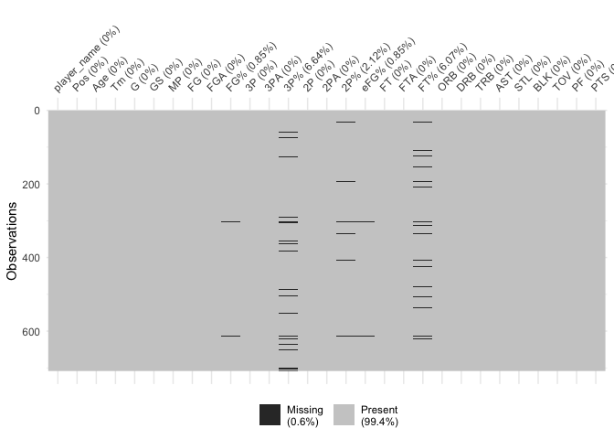

```r
#Check for missing values
sum(is.na(payroll))
sum(is.na(salary))
#Looking at the data frame there are 4 columns without data, there are 576 players.
576*4
#We should remove the spare columns
sum(is.na(statistics))
which(is.na(statistics))
naniar::vis_miss(statistics)
```

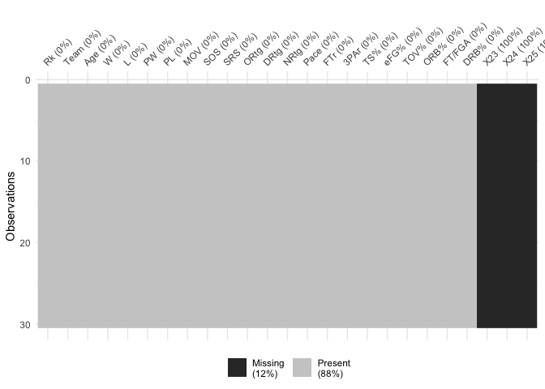

```r
#Looking at the data frame there are players with na for % results (2p%, 3p%, FT%) where they have not attempted a shot.
#There is no reason to remove these na's as they present a non event.
sum(is.na(team_statistics_1))
which(is.na(team_statistics_1))
naniar::vis_miss(team_statistics_1)
```

```r
#Looking at the data frame there are 3 columns without data.
#We should remove the spare columns
sum(is.na(team_statistics_2))
```

## Data Transformation

```r
#Remove unwanted data.
salary <-salary[setdiff(colnames(salary), c('X4','X5', 'X6', 'X7'))]

team_statistics_1 <-team_statistics_1[setdiff(colnames(team_statistics_1), c('X23','X24', 'X25'))]

#We need to combine players that played for mutliple teams, using group_by "player_name" and summarise the columns that are numeric.
statistics <- statistics %>%
group_by(player_name, Pos) %>%
summarise_each(funs(sum), 3:27)

#We should remove accents and periods from player names in the statistics data frame so it matches the salary data frame for later.
statistics$player_name <- statistics$player_name %>%
stringi::stri_trans_general("Latin-ASCII") %>%
stringr::str_replace_all(pattern = "\\.", replacement = "")

#Now we will also convert data that doesn't meet tidy data requirements (such as numbers at the start of variable names and %)
statistics <-rename(statistics,
                    FGp = `FG%`,
                    x3P = `3P`,
                    x3PA = `3PA`,
                    x3Pp = `3P%`,
                    x2P = `2P`,
                    x2PA = `2PA`,
                    x2Pp = `2P%`,
                    eFGp = `eFG%`,
                    FTp = `FT%`)

team_statistics_1 <-rename(team_statistics_1,
                           TSp = `TS%`,
                           eFGp = `eFG%`,
                           TOVp = `TOV%`,
                           ORBp = `ORB%`,
                           FTpFGA = `FT/FGA`,
                           DRBp = `DRB%`)

team_statistics_2 <-rename(team_statistics_2,
                           FGp = `FG%`,
                           x3P = `3P`,
                           x3PA = `3PA`,
                           x3Pp = `3P%`,
                           x2P = `2P`,
                           x2PA = `2PA`,
                           x2Pp = `2P%`,
                           FTp = `FT%`)
```

## Exploratory Analysis

**We want to generate more wins, our most obvious observations should start with team offensive and defensive prowess, so these are the statistical areas we will focus on:**

*ORtg: Offensive Rating; An estimate of points produced (players) or scored (teams) per 100 possessions

*DRtg : Defensive Rating; An estimate of points allowed per 100 possessions

*NRtg: Net Rating; an estimate of point differential per 100 possessions

*TOVp: Turnover Percentage; An estimate of turnovers committed per 100 plays

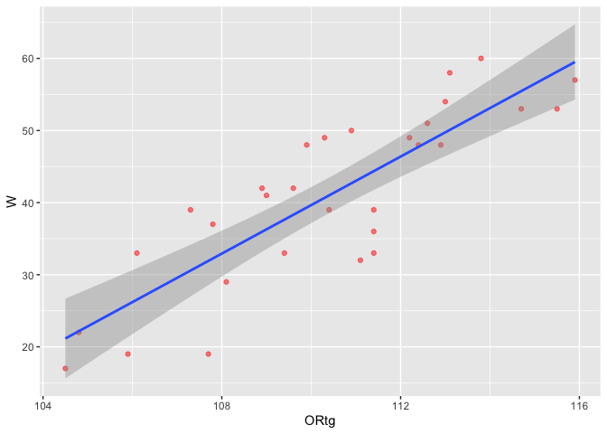

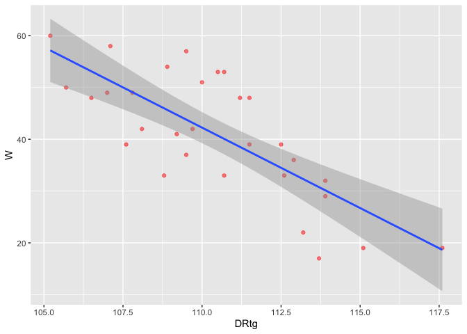

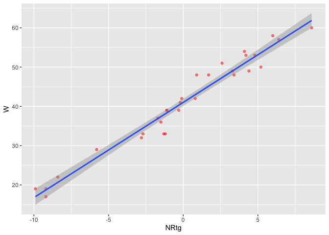

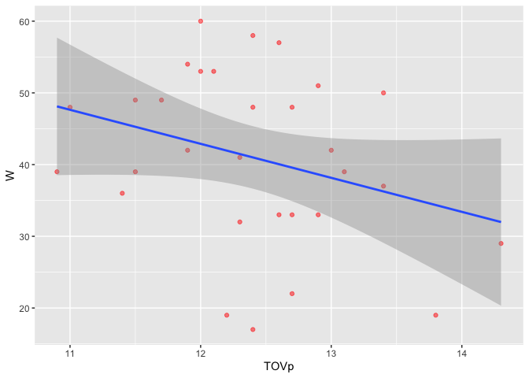

**ORtg shows a positive correlation to wins, while DRtg and TOVp show a negative correlation. NRtg (Net Rating) an estimate of point differential per possessions shows what looks like the highest correlation.**

```
## [1] 0.9800362
```

**Since both offensive (Offensive Rating) and defensive (Defensive Rating) measures play an important part in determining Net Rating and thus Wins we should look at a metric that measures most of these elements.**

**The NBA provides [^8][Efficiency](https://en.wikipedia.org/wiki/Efficiency_basketball), which is derived from basic individual statistics: points, rebounds, assists, steals, blocks and turnovers. The efficiency stat, in theory, accounts for both a player’s positive offensive contributions (points, assists offensive rebounds) and defensive contributions (defensive rebounds steals, blocks), while putting a negative emphasis on turnovers (loss of possession).**

**So we should take a look at those statistics to see if we get a linear relationship.**

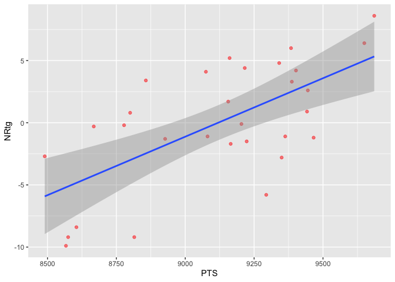

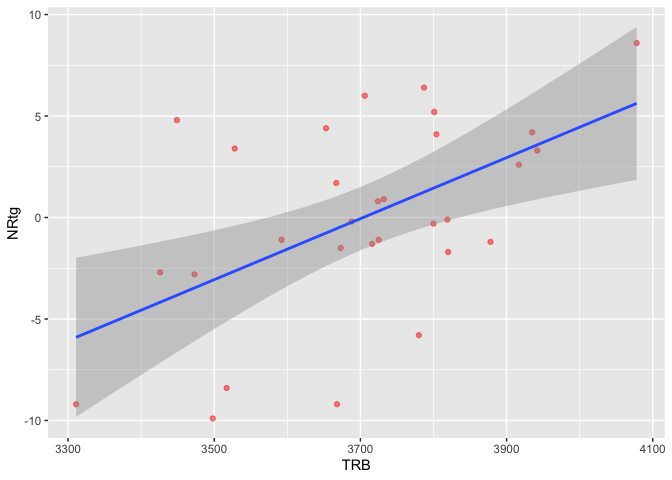

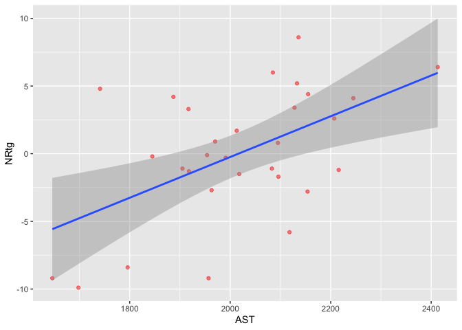

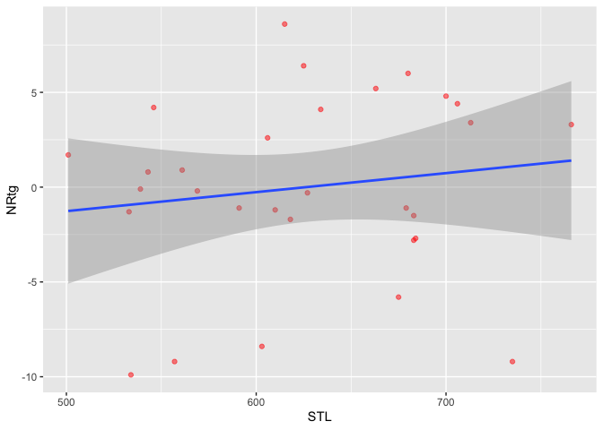

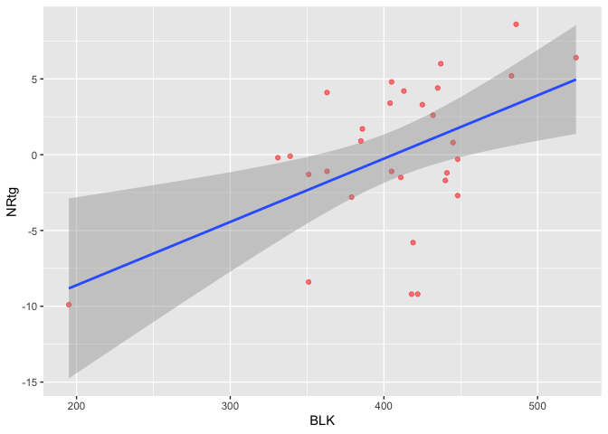

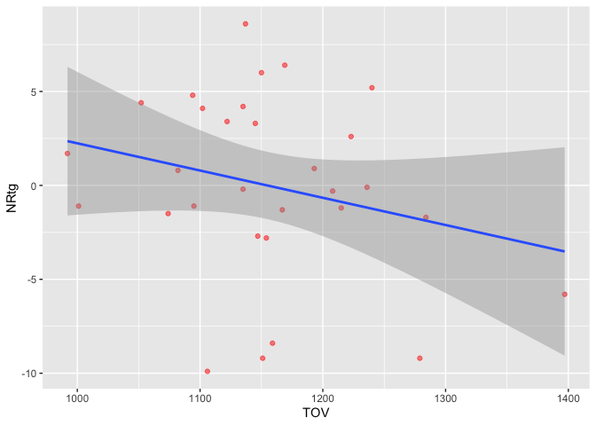

```
## # A tibble: 7 x 7
##   term         estimate std.error statistic p.value  conf.low conf.high
##   <chr>           <dbl>     <dbl>     <dbl>   <dbl>     <dbl>     <dbl>
## 1 (Intercept)   -66.2      18.4      -3.60  0.00151 -104.       -28.1
## 2 PTS_per_game    0.338     0.197     1.72  0.0994    -0.0693     0.746
## 3 REB_per_game    0.779     0.385     2.02  0.0549    -0.0178     1.58
## 4 AST_per_game    0.367     0.365     1.01  0.325     -0.388      1.12
## 5 STL_per_game    0.691     0.835     0.828 0.416     -1.04       2.42
## 6 BLK_per_game    1.53      1.01      1.52  0.143     -0.559      3.63
## 7 TOV_per_game   -2.03      0.579    -3.50  0.00195   -3.22      -0.827
```

**Our slope coefficient says that teams that get 1 more:** **PTS_per_game than the average team, score 0.34 more NRtg_per_game than the average team**  
**REB_per_game than the average team, score 0.78 more NRtg_per_game than the average team**  
**AST_per_game than the average team, score 0.37 more NRtg_per_game than the average team**  
**STL_per_game than the average team, score 0.69 more NRtg_per_game than the average team**  
**BLK_per_game than the average team, score 1.53 more NRtg_per_game than the average team**  
**TOV_per_game than the average team, score 2.02 less NRtg_per_game than the average team**

### Predicted Values

**Our model looks like:**

**$Net Rating = -66.19 + PTSpg + REBpg + ASTpg + STLpg + BLKpg -TOVpg$**

## Assumptions

### 1. The response variable should be continuous (i.e. ratio/interval)

**NRtg (Net Rating) is a measure of an estimate of point differential per 100 possessions, so is ratio scale of measurement.**

### 2. There are two or more explanatory variables that are either continuous of categorical

**Each of our explanatory variables are continuous.**

### 3. Independence of Observations

**There should be independence of observations.**

```
##  lag Autocorrelation D-W Statistic p-value
##    1        0.356662      1.237792    0.03
##  Alternative hypothesis: rho != 0
```

### 4. Linearity

**There should be a linear relationship between the response variable (NRtg) and each explanatory variable.**

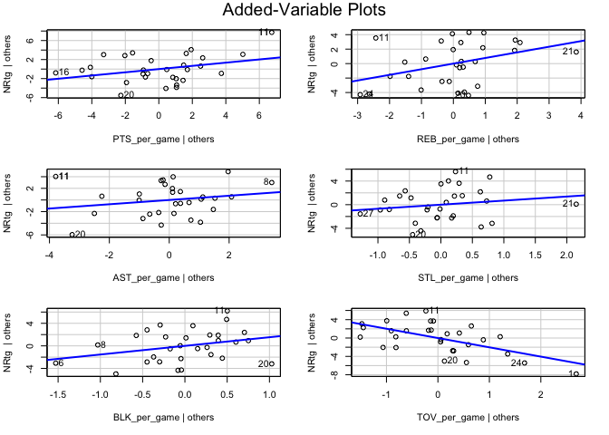

**We can see there is a linear relationship between the NRtg and each of our explanatory variable. STL_per_game is weak however.**

### 5. Outliers, Influential or High Leverage Points

**Outliers, Influential and/or high leverage points have the ability to influence our model, so there is a need to identify any and potentially remove them from the data.**

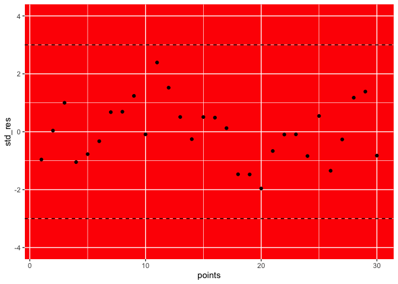

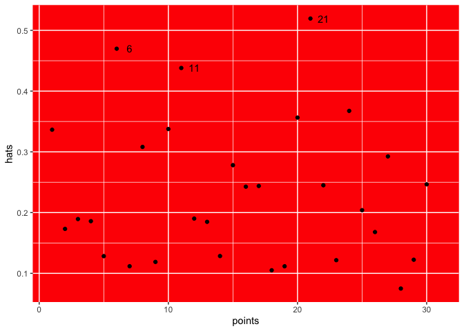

**There do not appear to be any leverage points as all hatvalues are closer to 0 than 1, although there are three points (6, 11, & 21) in particular that are above 0.4 that we should look at potentially investigating.**

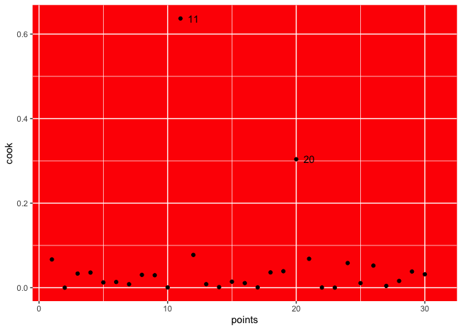

**It does not appear that points 11 or 20 are showing any influence or leverage in this instance, but this is the second time that point 11 has shown up in our checks for validity.**

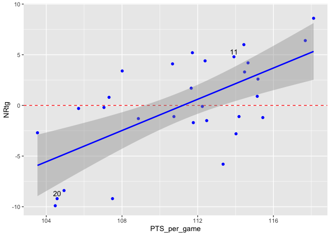

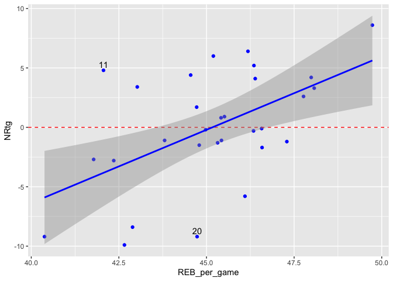

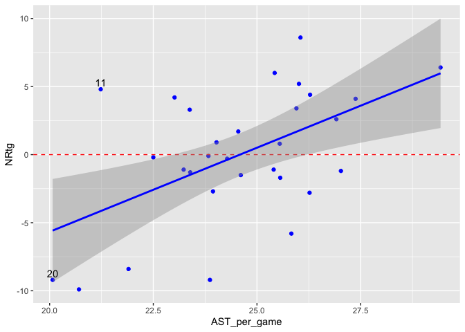

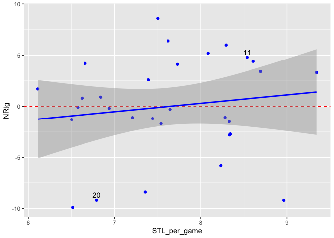

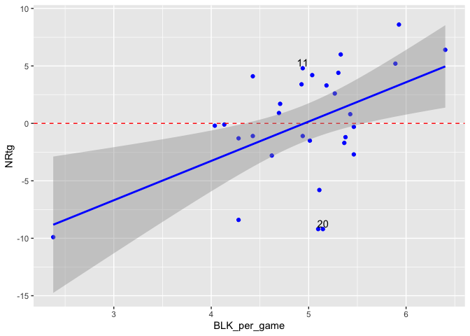

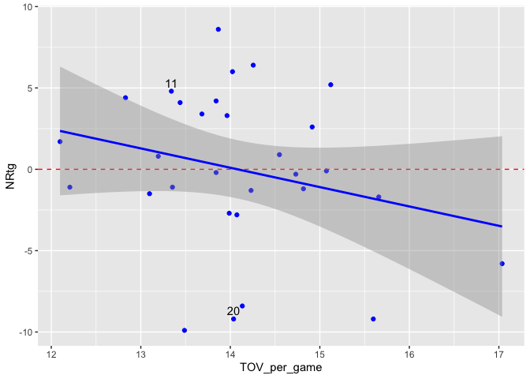

**Neither point 11 or 20 show high leverage or high influence.**

### 6. Homoscedasticity

**The data needs to show homoscedasticity.**

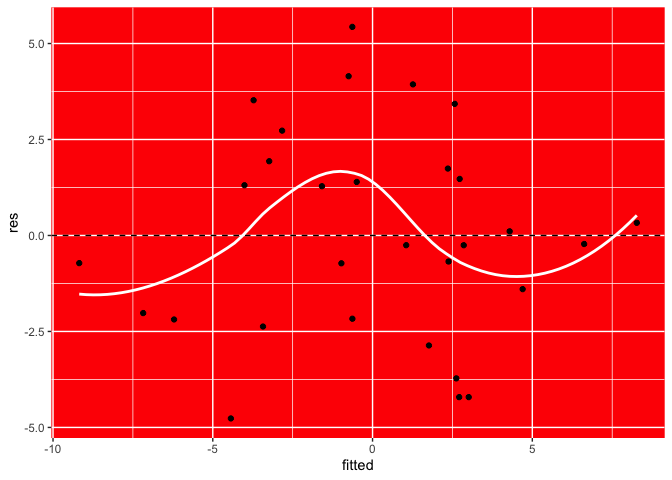

**This randomisation of the data shows homoscedasticity (constant variance), and as such we can be sure there appears to be no evidence of heteroscedasticity.**

### 7. Normality

**The residuals should be normally distributed.**

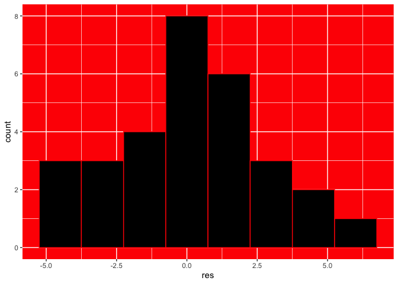

**The data points appear normally distributed, although there is a larger tail.**

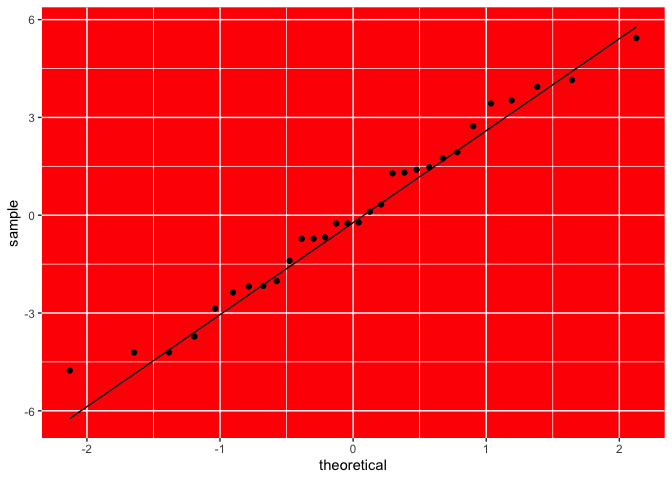

**The Q-Q plot shows that the points appear normally distributed.**

### 8. Multicollinearity

**There should be no multicollinearity between the explanatory variables.**

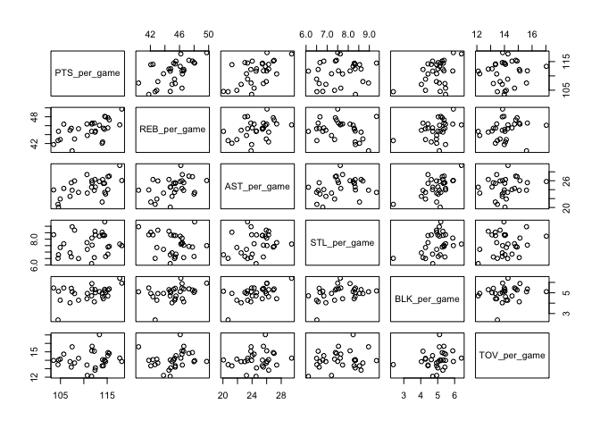

**There appears to be no evidence of a linear relationship between any of our explanatory variables.**

```
## PTS_per_game REB_per_game AST_per_game STL_per_game BLK_per_game TOV_per_game
##     2.053365     2.095556     1.833356     1.565518     1.714154     1.114201
```

```
## PTS_per_game REB_per_game AST_per_game STL_per_game BLK_per_game TOV_per_game
##     1.432957     1.447604     1.354015     1.251206     1.309257     1.055557
```

**The square root of the VIF shows how much greater the standard error in the relevant slope coefficient is, compared to if there was no relationship between predictors. e.g. PTS_per_game is 1.43 times larger than if there was a 0 correlation with the other explanatory variables.**

**This shows that there is no Multicollinearity.**

## Model Testing

### Applying the Model (Expected_NRtg v NRtg (2018-19))

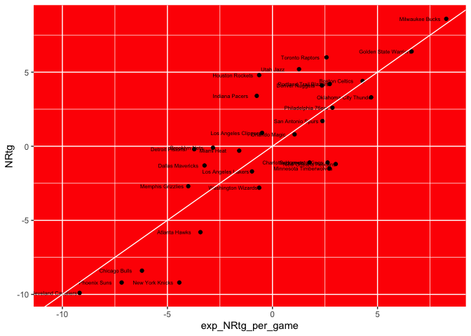

### Applying the Model (Expected_NRtg v Wins (2018-19))

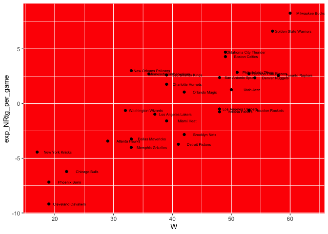

## Player Metrics

**We can calculate the number of minutes each team played per game on average across the league. Normally this would be 5 * 48 = 240 minutes, however there are games that go into overtime.**

```
## [1] 241.6463
```

### Adjusting Players Expected Performance Per Minutes Played

**Next we can create new statistics per game for each player, adjusted for average minutes played per game.**

### Expected Net Rating Per Player

**The exp_NRtg metric can be interpreted as the net effect a player has on the overall score between their team and the opposition’s team if all players are exactly like that player.**

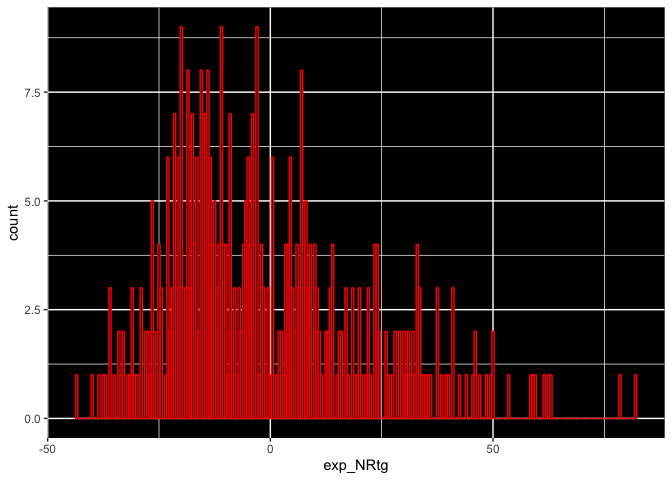

### Adding Salary & Position

**We need to add the players salary and positions back into our source to complete our analysis.**

### Selecting Players by Expected NRtg

**Let’s see who the best NRtg players are?**

```
## # A tibble: 447 x 4
## # Groups:   player_name [431]
##    player_name           Pos     salary exp_NRtg
##    <chr>                 <chr>    <dbl>    <dbl>
##  1 Anthony Davis         C     25434263     82.2
##  2 Hassan Whiteside      C     24434262     78.3
##  3 Andre Drummond        C     25434262     63.0
##  4 Rudy Gobert           C     23491573     62.6
##  5 Mitchell Robinson     C      1485440     61.6
##  6 Joel Embiid           C     25467250     59.6
##  7 Giannis Antetokounmpo PF    24157304     58.8
##  8 Nikola Vucevic        C     12750000     58.4
##  9 Robert Williams       C      1656600     53.7
## 10 Karl-Anthony Towns    C      7839435     50.2
## # … with 437 more rows
```

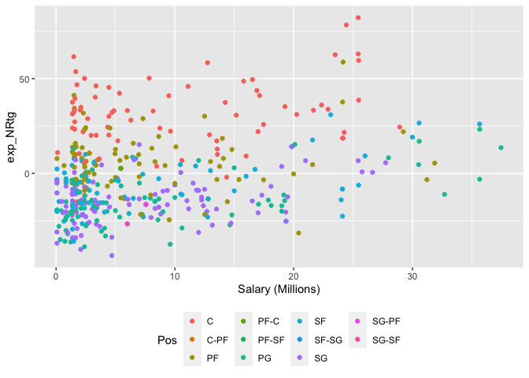

## Players to Target

**We need to come up with our targets, o we will look at the positions**

### Centre

**Centre is traditionally a position where the main asset offensively is scoring. A secondary asset is rebounds (offensive) and limiting turnovers. While defensively, rebounds (defensive) and blocks are a good measure of defensive worth.**

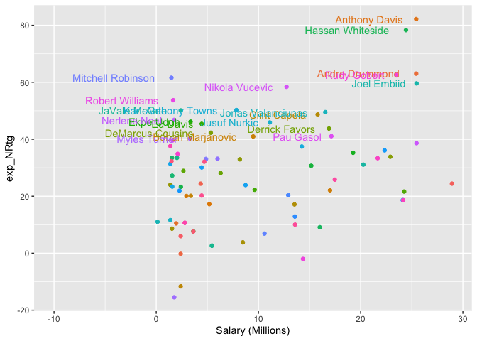

**Anthony Davis & Hassan Whiteside are the two best centres, however Mitchell Robinson shows tremendous value for money and this is who we should target. Robert Williams would be a good signing for our bench.**

### Power Forward

**Power Forward, similar to our centre is traditionally a position where the main asset offensively is scoring. A secondary asset is rebounds (offensive) and limiting turnovers. While defensively, rebounds (defensive) and blocks are a good measure of defensive worth.**

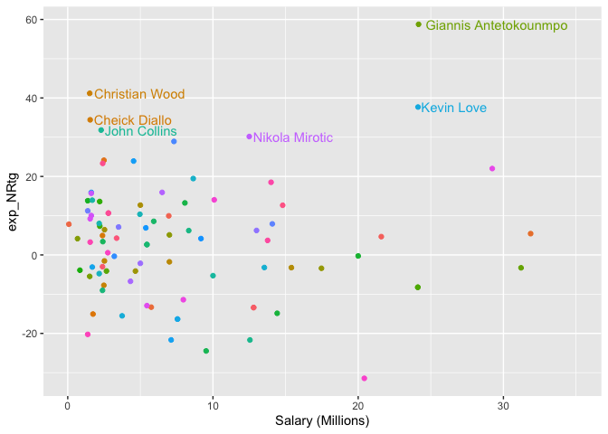

**Giannis Antetokounmpo is the best power forward in the league, his expected Net Rating is almost 50% better than the next best player, for $24million dollars, this may be worth the money, although Christian Wood and Cheick Diallo look like bargains and we should try and sign one or both of these players to help fill the rest of our roster.**

### Small Forward (Point Forward)

**Small Forward, is traditionally a position where the main asset offensively is scoring. A secondary assets is passing (assists) and limiting turnovers. While defensively, rebounds and steals are a good measure of defensive worth.**

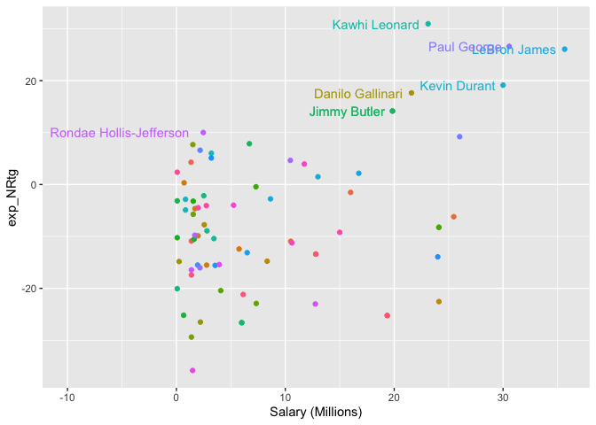

**There is not many players at a value price here. Kawhi Leonard is the standout and should be our target. While Rondae Hollis-Jefferson, should be a target for our bench.**

### Shooting Guard

**Like Small Forward, shooting guard is traditionally a position where the main asset offensively is scoring. A secondary assets is passing (assists) and limiting turnovers. While defensively, rebounds and steals are a good measure of defensive worth.**

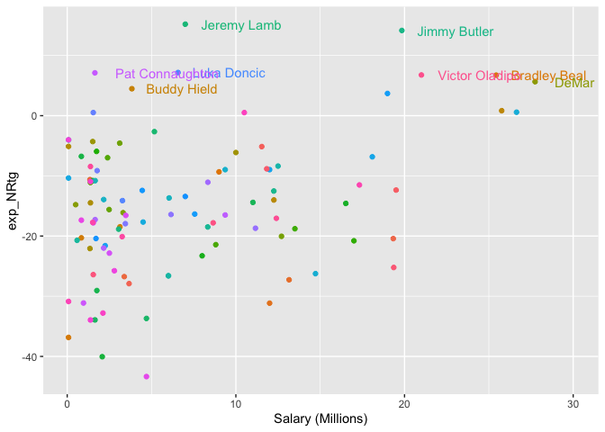

**Jeremy Lamb should be our target here. While Pat Connaughton and Luka Doncic would be good targets to fill the bench.**

### Point Guard

**Point Guard is traditionally a position played by a ball handler. The main asset offensively being scoring and passing (assists) and limiting turnovers. Defensively steals are a good measure of defensive worth.**

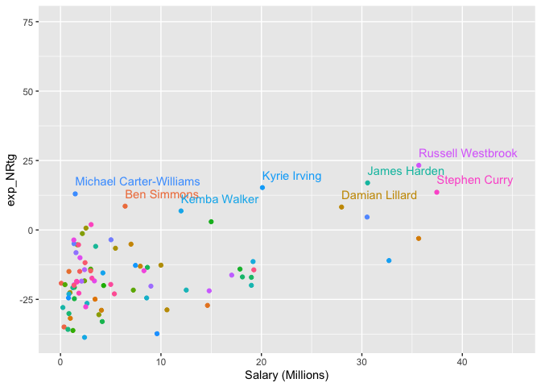

**Michael Carter Williams should be our target here. Ben Simmons would be a good signing to fill our bench roster.**

# Chicago Bulls 2019-20

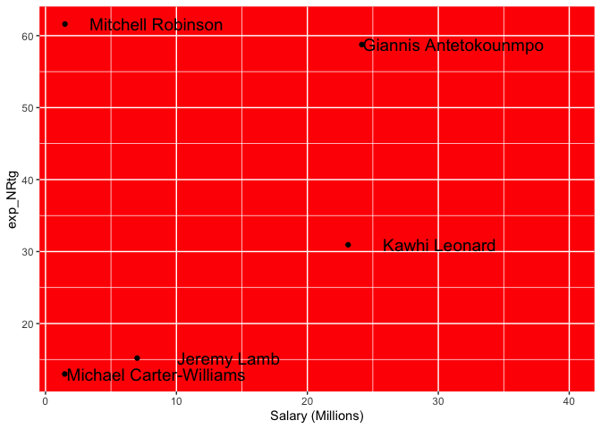

```
## [1] 57224892
```

| player_name | Pos | salary |
| --- | --- | --- |
| Giannis Antetokounmpo | PF | 24157304 |
| Kawhi Leonard | SF | 23114066 |
| Jeremy Lamb | SG | 7000000 |
| Mitchell Robinson | C | 1485440 |
| Michael Carter-Williams | PG | 1468082 |

**Our starting team would cost $57,224,892. Leaving us approximately $60 million to secure the rest of the roster.**

**As mentioned in the positional analysis there are other players we should look to target, just outside this list of starters.**

[figure not shown]

Est. 1966

## References

[^1]: Hoops Hype
[^2]: Wikipedia
[^3]: basketball-reference.com
[^4]: hoopshype.com/salaries
[^5]: hoopshype.com/salaries
[^6]: basketball-reference.com
[^7]: basketball-reference.com
[^8]: Efficiency